# ChemModLab Full Dataset Test and New Functions

Jeremy Ash

February 9, 2017

# Deciding on journal for r-package

## Statistics Journals

- JSS
  - impact factor: 3.8
  - long time to acceptance: [1.5 years on average!](https://www.r-bloggers.com/time-to-accept-it-publishing-in-the-journal-of-statistical-software/)
  - [reviewers](http://robjhyndman.com/hyndsight/jss-rpackages/) like packages to have been on CRAN for awhile and to have a user base
  - Highly selective
  - More info on [review process](https://www.jstatsoft.org/information/authors)
- R Journal
  - impact factor: 1.02
  - length
    - typical paper ranges 10-20 pages. Have seen some 30 pages in recent publication
  - code + figures
  - fast review process
    - “The R Journal intends to reach a wide audience and have a fast-track but thorough review process. Papers are expected to be reasonably short, clearly written, not too technical, and of course focused on R.”

## Cheminformatics Journals

- Journal of Cheminformatics (application note)
  - impact factor: 3.9
  - length
    - about 8 pages with figures.
  - [example](https://jcheminf.springeropen.com/articles/10.1186/s13321-016-0158-y)
- Journal of Chemical Information and Modeling (application note)
  - impact factor: 3.7
  - length
    - About [5 pages with figures](http://pubs.acs.org/paragonplus/submission/jcisd8/jcisd8_authguide.pdf)
    - “Submissions should be no longer than 5000 words and contain at least one figure. This word count includes the abstract, text, references, author names, and all graphics. You may approximate the length of figures, schemes, and tables by counting single-column images as 300 words and double-column as 600 words (this count assumes that they will occupy ¼ and ½ page, respectively, at final production size).”
  - [example](http://pubs.acs.org/doi/pdf/10.1021/acs.jcim.6b00283) (tool to interactively select number of tests for initial enrichment!)
- Bioinformatics (application note)
  - impact factor: 5.8
  - less visibility for Cheminformatics community
    - post docs in my lab say that the frequently review the most recently published papers in JCIM and J of Chem but not bioinformatics
  - length
    - about 2 pages
  - post docs tell me that the application note is highly selective
  - [example](https://academic.oup.com/bioinformatics/article/33/1/145/2525681/Precrec-fast-and-accurate-precision-recall-and-ROC)

## General Paper Questions

- Can we publish in one statistics journal and one cheminformatics journal? Wont there need to be substantial differences in the content?
- Will we have trouble publishing description of the same methods, dataset, etc if they are in the ChemModLab paper that is already published?

# Correction of SVM and PLSLDA binary predictions

## PLSLDA

PLSLDA had classes coded in 1 and 2 instead of 0 and 1

```
> summary(pred_old$PLSLDA)
   Min. 1st Qu.  Median    Mean 3rd Qu.    Max.
      1       1       1       1       1       2
```

There was a problem converting a factor vector to a numeric vector.

```
lda.a$class
  [1] 0 0 0 0 0 0 0 0 0 0 0 0 0 0 0 0 0 0 0 0 0 0 0 0 0 0 0 0 0 0 0 0 0 0 0 0 0 0 0 0 0 0 0 0 0 0 0 0 0
Levels: 0 1
Ypred[, a] <- lda.a$class
Ypred[, a]
  [1] 1 1 1 1 1 1 1 1 1 1 1 1 1 1 1 1 1 1 1 1 1 1 1 1 1 1 1 1 1 1 1 1 1 1 1 1 1 1 1 1 1 1 1 1 1 1 1 1 1
> Ypred[, a] <- as.numeric(levels(lda.a$class))[lda.a$class]
> Ypred[, a]
  [1] 0 0 0 0 0 0 0 0 0 0 0 0 0 0 0 0 0 0 0 0 0 0 0 0 0 0 0 0 0 0 0 0 0 0 0 0 0 0 0 0 0 0 0 0 0 0 0 0 0
```

I corrected this using the same syntax used for the other model fitting functions.

```
work.pred[fold.id==id] <- work.meth$Ypred[, nLV.ZG]
work.pred[fold.id==id] <-
        as.numeric(levels(as.factor(work.data$y)))[work.meth$Ypred[, nLV.ZG]]
```

## SVM

SVM probabilities are the probability of class 0 instead of class 1

```
> cbind(prob_new$SVM, pred_new$SVM)[1:10,]
           [,1] [,2]
 [1,] 0.4124680    0
 [2,] 0.1496754    0
 [3,] 0.9742051    0
 [4,] 0.9890491    0
 [5,] 0.9883893    0
 [6,] 0.9887811    0
 [7,] 0.9877279    0
 [8,] 0.9947616    0
 [9,] 0.1565374    0
[10,] 0.9946352    0
```

Corrected this by referring to the column of the predicted probabilities explicitly, instead of assuming I knew the right index:

```
> head(attr(temp.prob, "probabilities"))
                 1           0
6603320 0.21882653 0.781173470
2082    0.99046402 0.009535982
4993    0.50775804 0.492241957
658341  0.29190896 0.708091036
662613  0.01162110 0.988378902
2794    0.01163473 0.988365267

temp.prob <- predict( work.meth, work.data[fold.id==id,c(FALSE,varying.cols)], probability=TRUE )
work.prob[fold.id==id] <- attr(temp.prob, "probabilities")[,"1"]
```

# Analysis of MD-QSAR Dataset

Reading in the data

```r
desc_lengths <- c()
fing <- read.csv("procDesFingMACCS_all.csv", row.names = 1)
fing <- fing[-findCorrelation(cor(fing), cutoff = .9)]
desc_lengths <- c(desc_lengths, ncol(fing))
twoD <- read.csv("procDes2D_all.csv",row.names = 1)
twoD <- twoD[-findCorrelation(cor(twoD), cutoff = .9)]
desc_lengths <- c(desc_lengths, ncol(twoD))
threeD <- read.csv("procDes3D_all.csv", row.names = 1)
threeD <- threeD[-findCorrelation(cor(threeD), cutoff = .9)]
desc_lengths <- c(desc_lengths, ncol(threeD))
fourD <- read.csv("procDes4D_all.csv", row.names = 1)
fourD <- fourD[-findCorrelation(cor(fourD), cutoff = .9)]
desc_lengths <- c(desc_lengths, ncol(fourD))

pki <- read.csv("pkis_right_labels.csv")
pki$rowid = as.character(pki$rowid)

all = merge(pki, fing, by.x = "rowid", by.y= "row.names")
all = merge(all, twoD, by.x= "rowid", by.y= "row.names")
all = merge(all, threeD, by.x= "rowid", by.y= "row.names")
all = merge(all, fourD, by.x= "rowid", by.y= "row.names")

desc_lengths <- c(desc_lengths, ncol(all[,-c(1,2)]))
all = cbind(all, all[,-c(1,2)])

CSARidx = 1:39
modelidx = 40:87
model_set <- all[modelidx, ]
head(model_set[1:6])
```

```
##       rowid  pki Bit.3 Bit.7 Bit.8 Bit.9
## 40 Model_01 4.60     1     0     1     1
## 41 Model_02 4.64     1     0     1     1
## 42 Model_03 5.09     1     0     1     1
## 43 Model_04 5.24     1     1     1     1
## 44 Model_05 5.33     1     1     1     1
## 45 Model_06 5.40     1     0     1     1
```

The number of descriptors in each descriptor set

```r
desc_lengths
```

```
## [1]  97  65  20  44 226
```

There are only 48 compounds in this dataset. Don’t know if repeated 10 fold cross validation is the best thing to do in this case, but that is what I did. We could do LOOCV, but then it doesn’t make sense to do repeats.

```r
dim(model_set)
```

```
## [1]  48 454
```

The descriptor set names

```r
des.names <- c("Fing", "2D", "3D", "MD", "all")
```

## Analyze descriptor sets alone and combination of all

Interestingly, do not see any PLS errors as I had when analyzing the USArrests data set.

```r
cml <- ModelTrain(model_set, ids = T, xcol.lengths = desc_lengths,
                  des.names = c("Fing", "2D", "3D", "MD", "all"))
```

For the one of the consistently best performing models (PLS - see CombineSplits results below), the MD descriptors have predictions of pki for the most active compounds that are approximately as good as (or better than) those of other descriptor sets. MD descriptors are slightly better at identifying the very most active compounds with PLS. All models seem to be under predicting the activity of the most active compounds. For some reason RF (another best perfoming model) is not plotting. I am looking into this.

Question: if a continuous measure of activity is used and many of the n most active compounds have their activity predicted by a model, is it possible for the accumulation curve to have a steeper slope than the ideal curve? I understand that any member of the set of most active compounds, wont have many compounds more active than it, so this is unlikely. A more than ideal accumulation curve might be problematic, but I guess it is unlikely enough to not worry about.

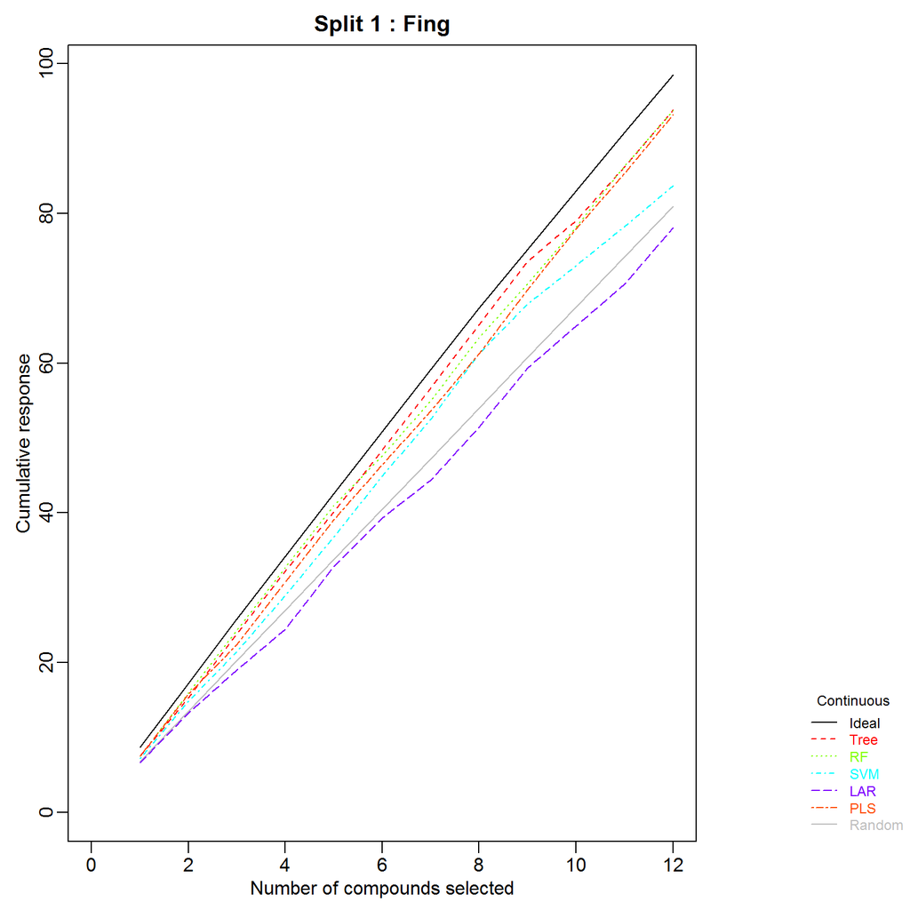

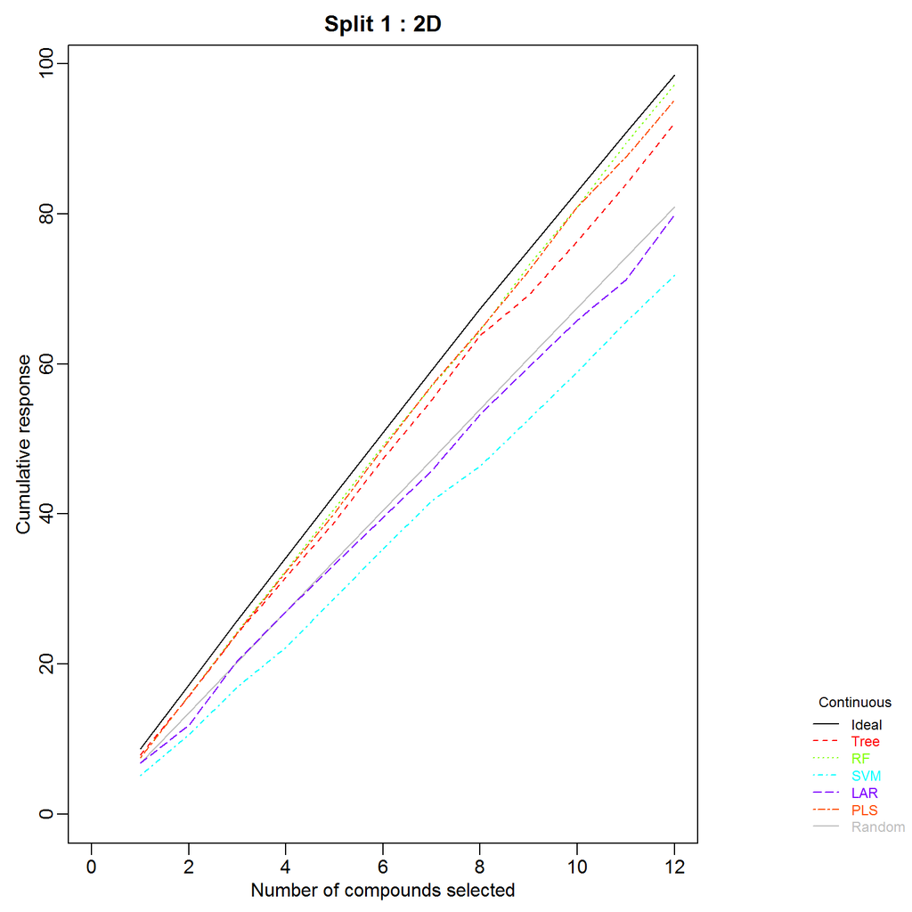

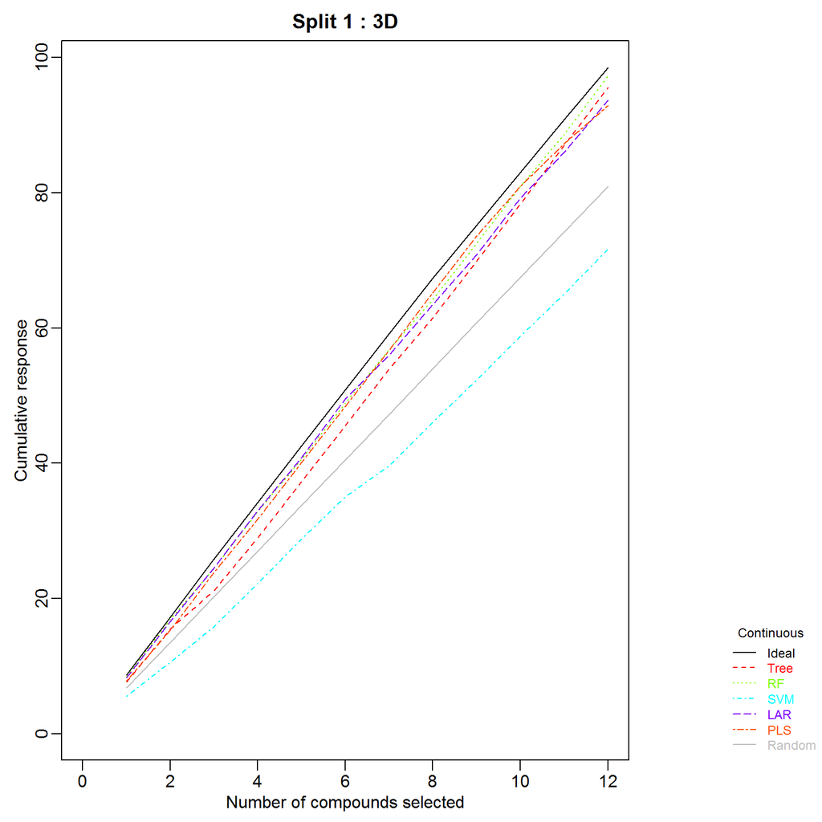

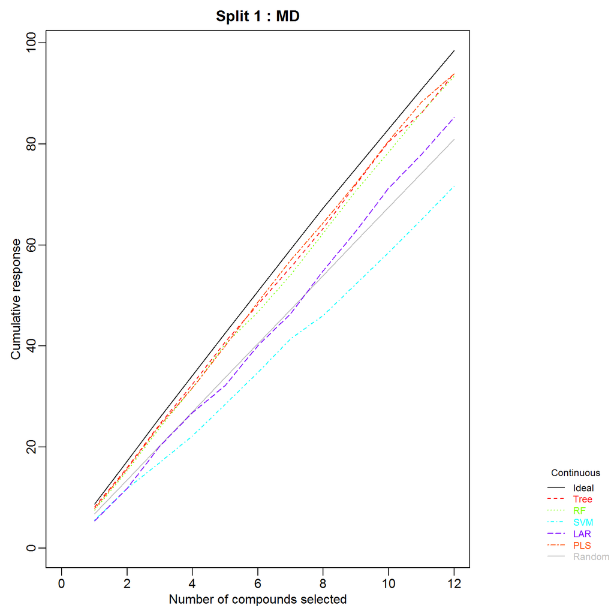

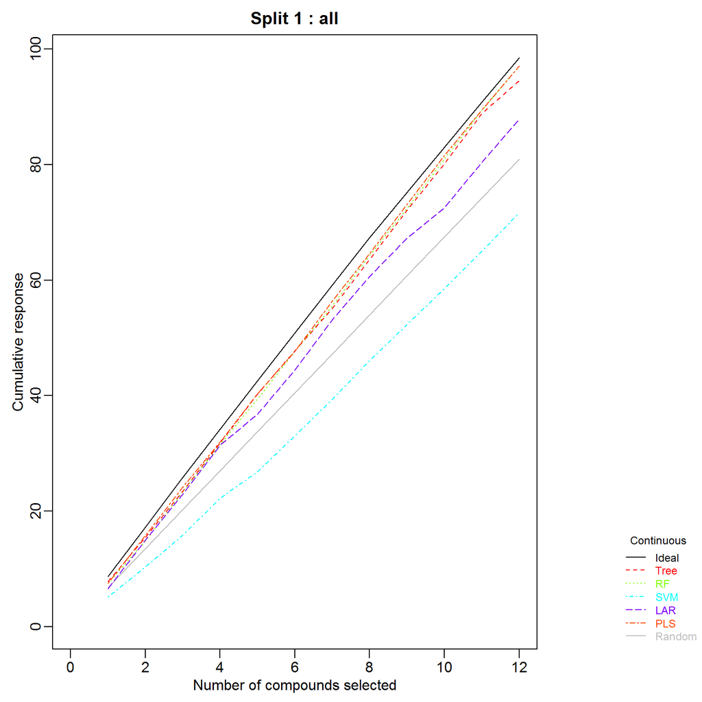

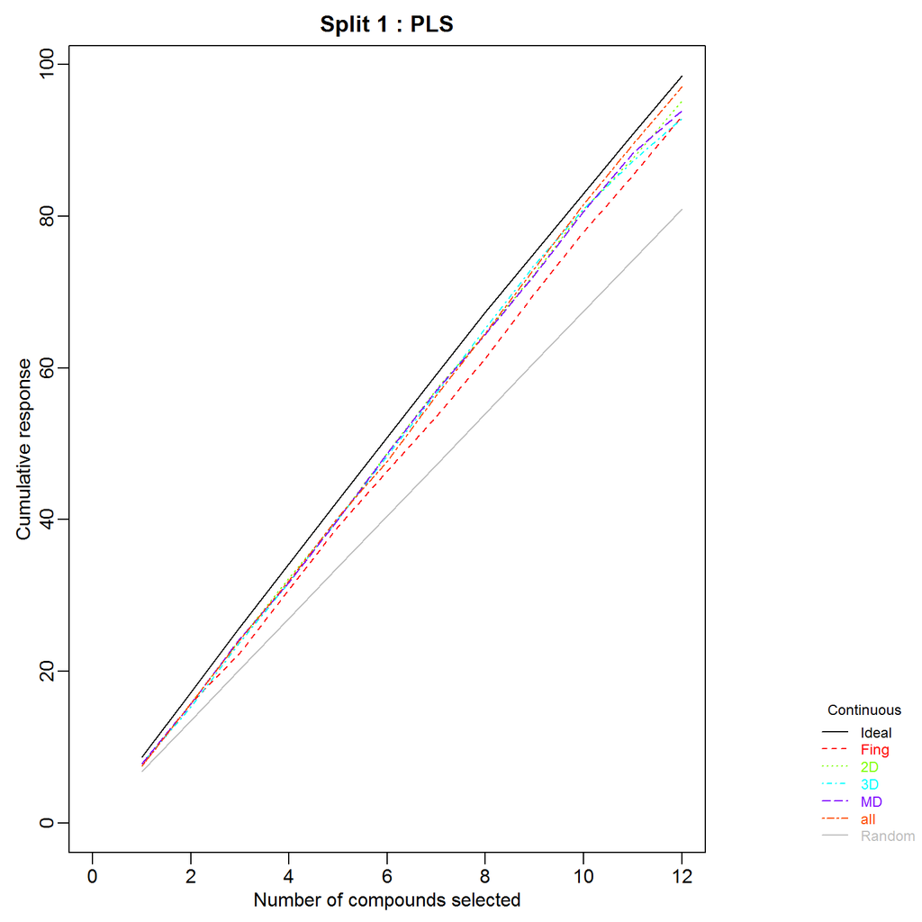

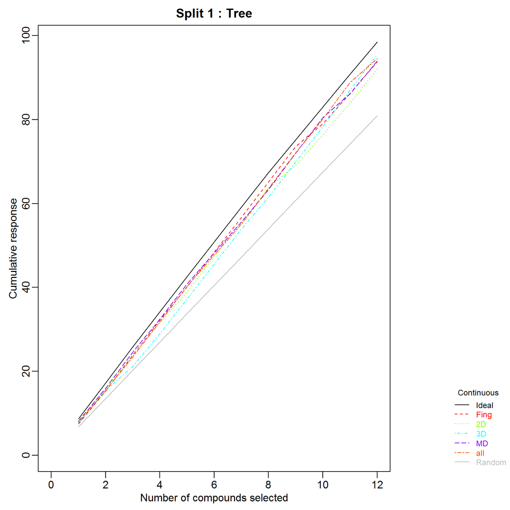

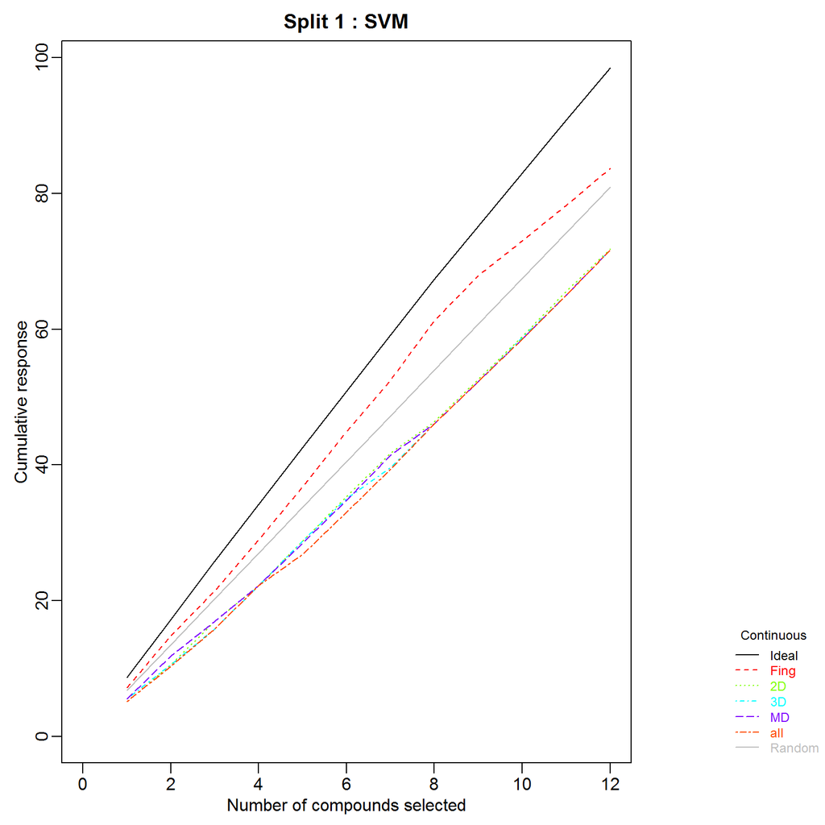

```r
plot(cml, splits = 1)
```

Multiple comparison plots show that the PLS and RF models consistently perform the best. The descriptor set containing all descriptors is not significantly different from the best performin models using all metrics.

```r
CombineSplits(cml, at = 12)
```

```
##    Analysis of Variance on: 'enhancement'
##  Using factors: Split and Descriptor/Method combination
## Source    DF          SS          MS           F   p-value
## Model     26    8.480764    0.326183   94.698923    <.0001
## Error     48    0.165332    0.003444
## Total     74    8.646096
##       R-Square   Coef Var   Root MSE       Mean
##         0.9809     4.4927     0.0587     1.3063
## Source       DF         SS         MS          F   p-value
## Split         2   1.35e-02   6.75e-03   1.96e+00    0.1399
## Desc/Meth    24   8.47e+00   3.53e-01   1.02e+02    <.0001
```

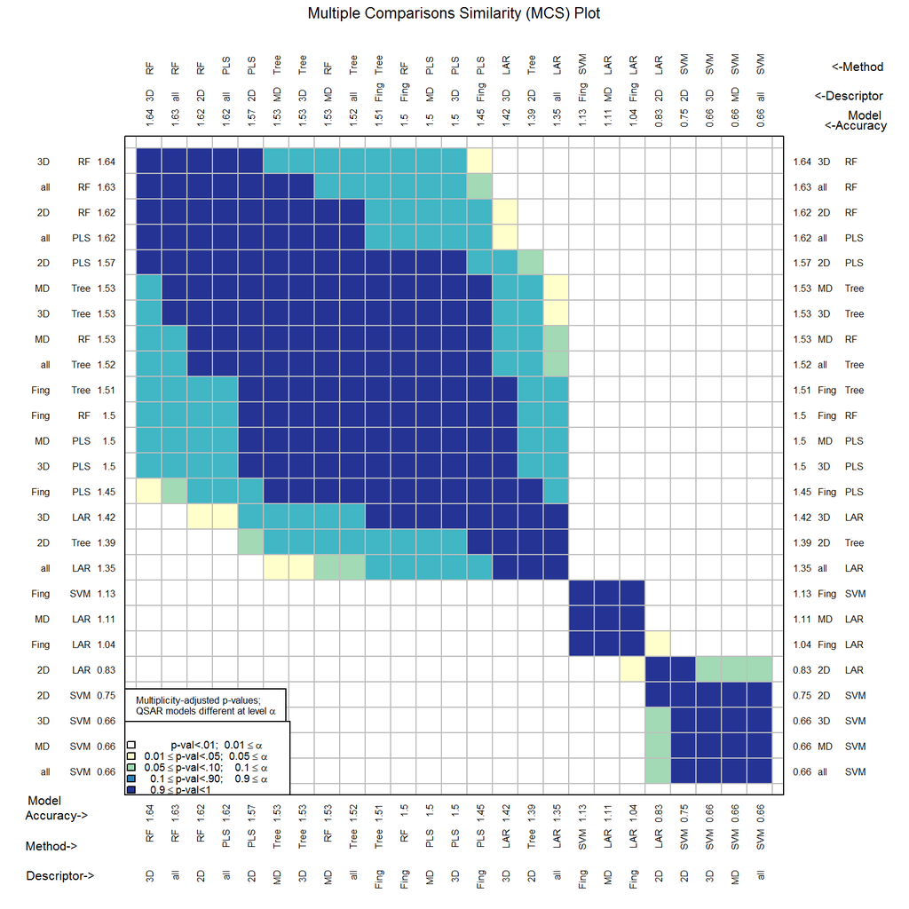

```r
CombineSplits(cml, "R2")
```

```
##    Analysis of Variance on: 'R2'
##  Using factors: Split and Descriptor/Method combination
## Source    DF          SS          MS           F   p-value
## Model     26    4.110490    0.158096   77.326620    <.0001
## Error     48    0.098137    0.002045
## Total     74    4.208627
##       R-Square   Coef Var   Root MSE       Mean
##         0.9767    11.9644     0.0452     0.3779
## Source       DF         SS         MS          F   p-value
## Split         2    0.01783    0.00892    4.36140    0.0178
## Desc/Meth    24    4.09266    0.17053   83.40706    <.0001
```

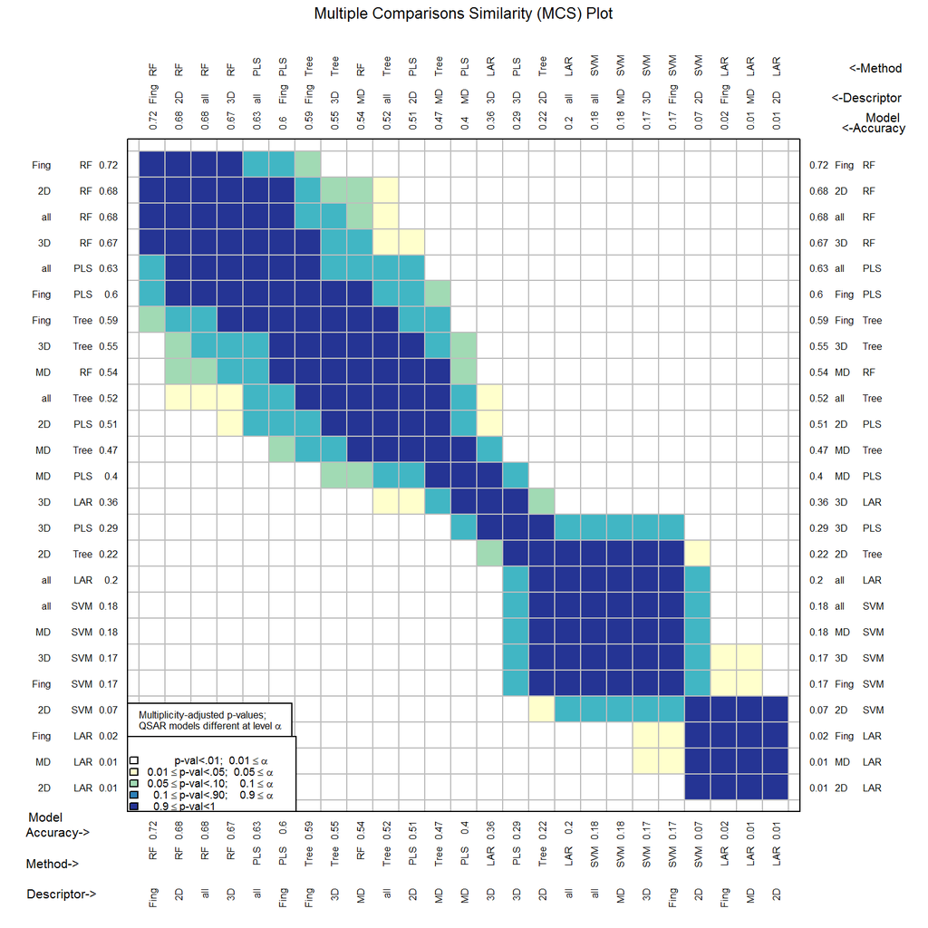

```r
CombineSplits(cml, "rho")
```

```
##    Analysis of Variance on: 'rho'
##  Using factors: Split and Descriptor/Method combination
## Source    DF          SS          MS           F   p-value
## Model     26   1.286e+01   4.946e-01   1.331e+02    <.0001
## Error     48   1.784e-01   3.716e-03
## Total     74   1.304e+01
##       R-Square   Coef Var   Root MSE       Mean
##         0.9863    13.9442     0.0610     0.4372
## Source       DF         SS         MS          F   p-value
## Split         2   9.94e-03   4.97e-03   1.34e+00    0.2533
## Desc/Meth    24   1.29e+01   5.35e-01   1.44e+02    <.0001
```

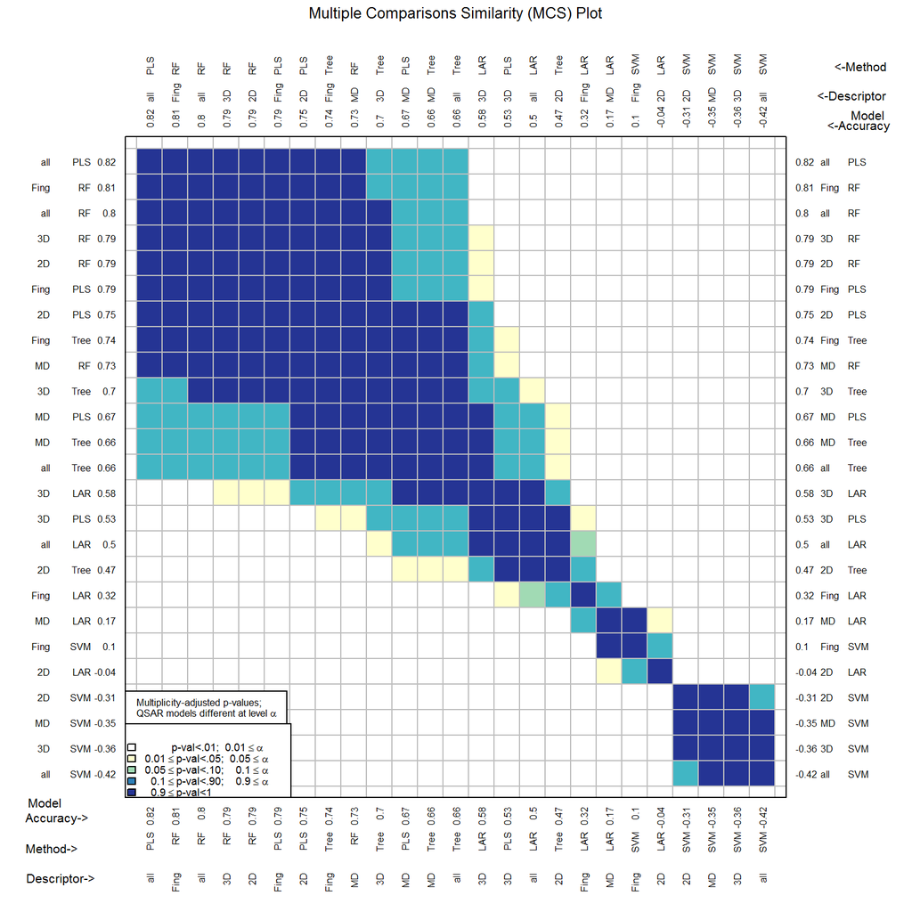

What is going on with RMSE?

```r
CombineSplits(cml, "RMSE")
```

```
##    Analysis of Variance on: 'RMSE'
##  Using factors: Split and Descriptor/Method combination
## Source    DF          SS          MS           F   p-value
## Model     26   4.358e+10   1.676e+09   7.458e+00    <.0001
## Error     48   1.079e+10   2.247e+08
## Total     74   5.437e+10
##       R-Square   Coef Var   Root MSE       Mean
##       8.02e-01   3.05e+02   1.50e+04   4.92e+03
## Source       DF         SS         MS          F   p-value
## Split         2   4.57e+08   2.28e+08   1.02e+00    0.3474
## Desc/Meth    24   4.31e+10   1.80e+09   8.00e+00    <.0001
```

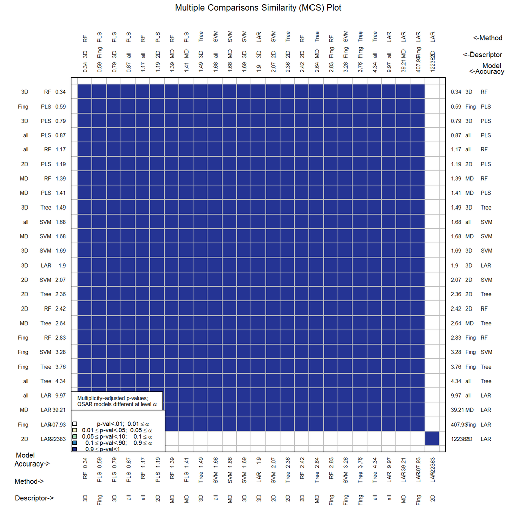

## Use 10 splits to see if there are more significant differences

```r
cml <- ModelTrain(model_set, ids = T, xcol.lengths = desc_lengths,
                  des.names = c("Fing", "2D", "3D", "MD", "all"),
                  nsplits = 10)
```

```r
CombineSplits(cml)
```

```
##    Analysis of Variance on: 'enhancement'
##  Using factors: Split and Descriptor/Method combination
## Source    DF          SS          MS           F   p-value
## Model     33   2.379e+01   7.210e-01   1.264e+02    <.0001
## Error    216   1.232e+00   5.703e-03
## Total    249   2.503e+01
##       R-Square   Coef Var   Root MSE       Mean
##         0.9508     5.7258     0.0755     1.3188
## Source       DF         SS         MS          F   p-value
## Split         9   7.54e-02   8.38e-03   1.47e+00    0.3731
## Desc/Meth    24   2.37e+01   9.88e-01   1.73e+02    <.0001
```

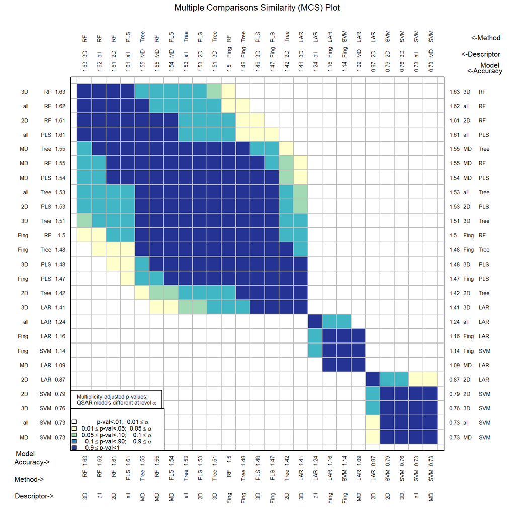

```r
CombineSplits(cml, "R2")
```

```
##    Analysis of Variance on: 'R2'
##  Using factors: Split and Descriptor/Method combination
## Source    DF          SS          MS           F   p-value
## Model     33   1.307e+01   3.960e-01   1.332e+02    <.0001
## Error    216   6.423e-01   2.974e-03
## Total    249   1.371e+01
##       R-Square   Coef Var   Root MSE       Mean
##         0.9531    14.9411     0.0545     0.3650
## Source       DF         SS         MS          F   p-value
## Split         9     0.1286     0.0143     4.8039    0.0014
## Desc/Meth    24    12.9381     0.5391   181.2843    <.0001
```

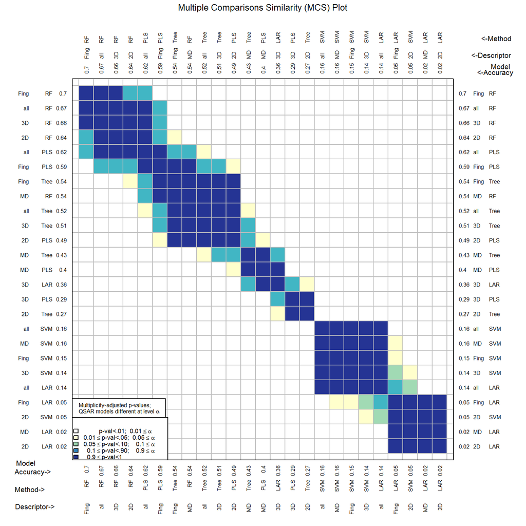

```r
CombineSplits(cml, "rho")
```

```
##    Analysis of Variance on: 'rho'
##  Using factors: Split and Descriptor/Method combination
## Source    DF          SS          MS           F   p-value
## Model     33   3.956e+01   1.199e+00   2.159e+02    <.0001
## Error    216   1.199e+00   5.551e-03
## Total    249   4.075e+01
##       R-Square   Coef Var   Root MSE       Mean
##         0.9706    16.9487     0.0745     0.4396
## Source       DF         SS         MS          F   p-value
## Split         9   4.37e-02   4.86e-03   8.75e-01    0.7856
## Desc/Meth    24   3.95e+01   1.65e+00   2.97e+02    <.0001
```

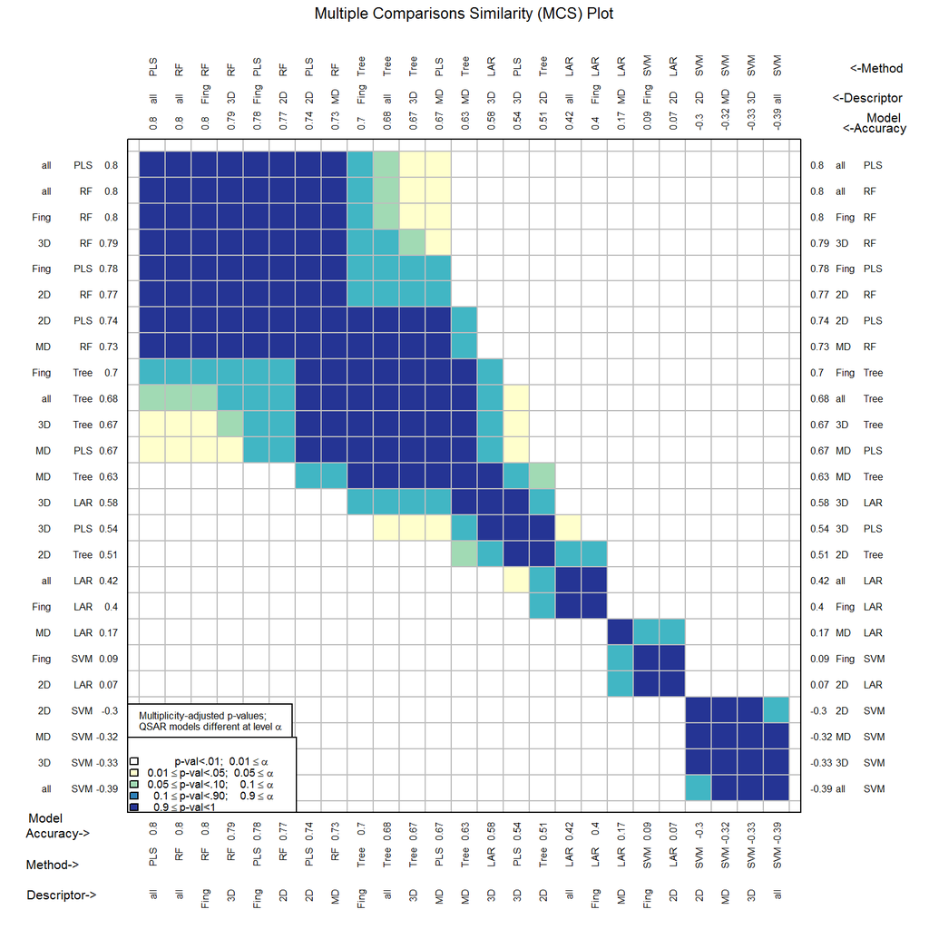

```r
CombineSplits(cml, "RMSE")
```

```
##    Analysis of Variance on: 'RMSE'
##  Using factors: Split and Descriptor/Method combination
## Source    DF          SS          MS           F   p-value
## Model     33   2.213e+11   6.706e+09   1.005e+01    <.0001
## Error    216   1.441e+11   6.673e+08
## Total    249   3.654e+11
##       R-Square   Coef Var   Root MSE       Mean
##       6.06e-01   4.30e+02   2.58e+04   6.00e+03
## Source       DF         SS         MS          F   p-value
## Split         9   6.01e+09   6.68e+08   1.00e+00    0.7068
## Desc/Meth    24   2.15e+11   8.97e+09   1.34e+01    <.0001
```

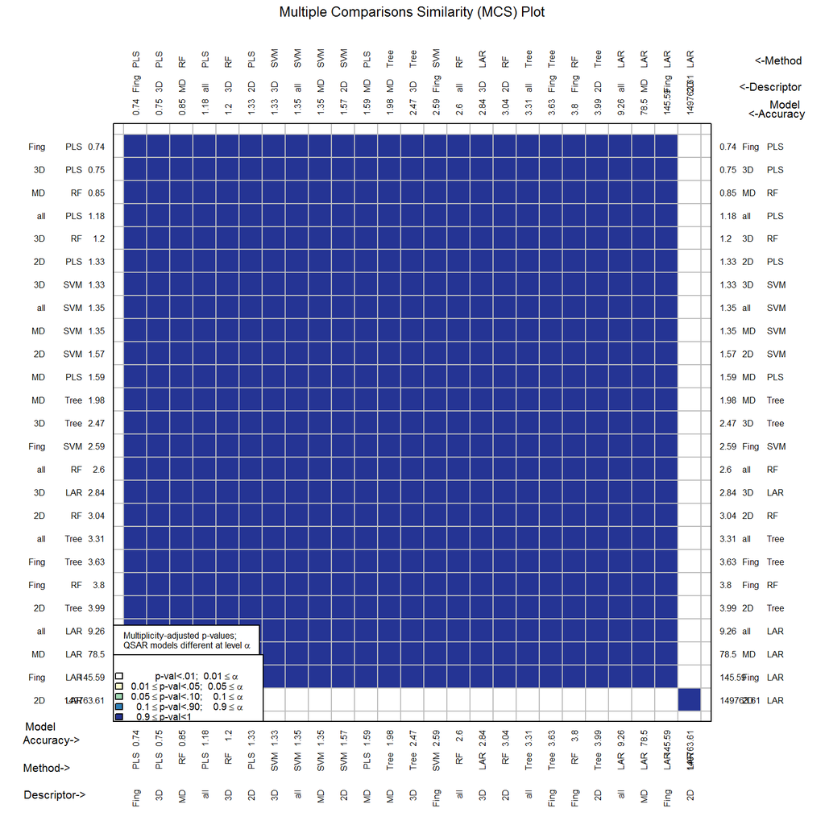

## Analyzing all descriptor set combinations

```r
desc = list(fing = fing, twoD = twoD, threeD = threeD, fourD = fourD)
des.names <- c("Fing", "2D", "3D", "MD", "model_set")
sets <- c("F", "2", "3", "M")

for(i in 1:4){
  for(j in 1:(i)){
    if(i!=j){
      data <- merge(desc[[i]], desc[[j]], by.x = "row.names", by.y= "row.names")
      desc_lengths <- c(desc_lengths, ncol(data[, -1]))
      model_set <- merge(model_set, data, by.x = "rowid", by.y= "Row.names")
      des.names <- c(des.names, paste(sets[i],sets[j],sep=""))
    }
  }
}

for(i in 1:4){
  indices <- seq(1,4)[-i]
  data = merge(desc[[indices[1]]], desc[[indices[2]]],
               by.x = "row.names", by.y= "row.names")
  data = merge(data, desc[[indices[3]]], by.x = "Row.names",
               by.y= "row.names")
  desc_lengths <- c(desc_lengths, ncol(data[, -1]))
  model_set <- merge(model_set, data, by.x = "rowid", by.y= "Row.names")
  des.names <- c(des.names, paste(sets[indices[1]],
                                  sets[indices[2]],
                                  sets[indices[3]], sep=""))
}
```

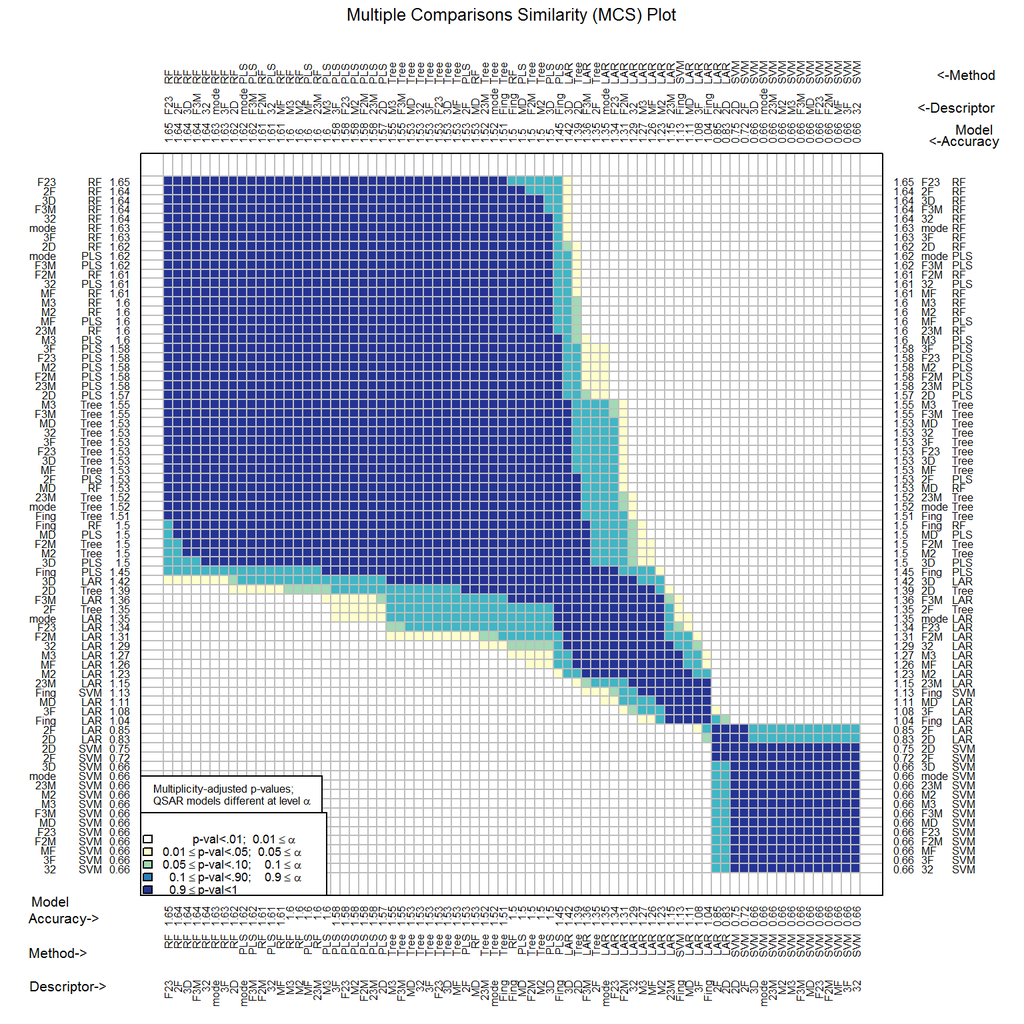

```r
cml <- ModelTrain(model_set, ids = T, xcol.lengths = desc_lengths,
                  des.names = des.names)

CombineSplits(cml)
```

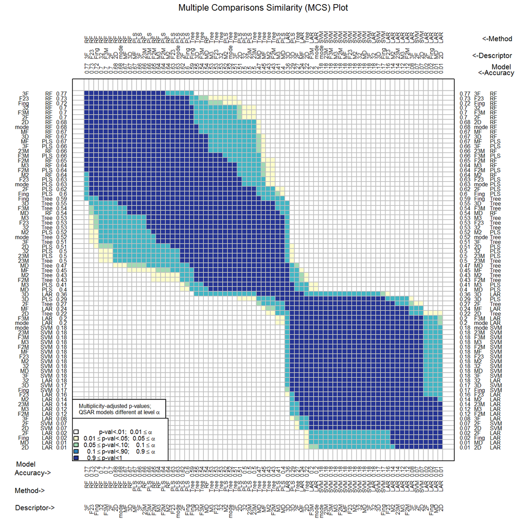

```r
CombineSplits(cml, "R2")
```

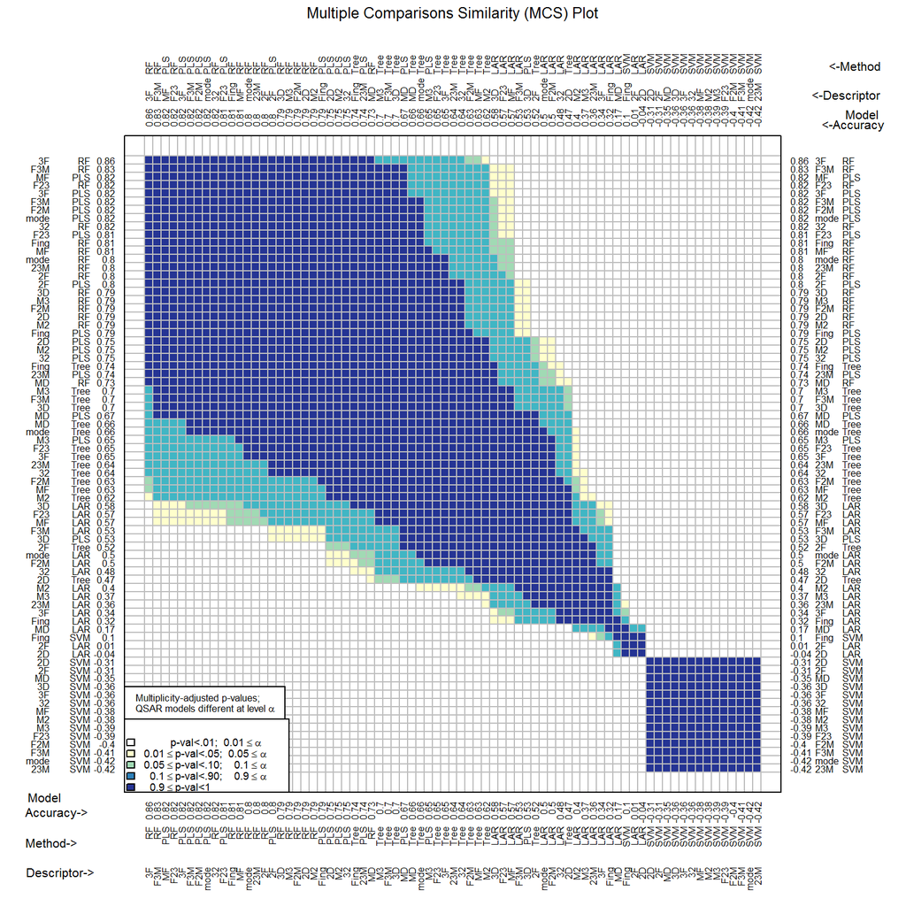

```r
CombineSplits(cml, "rho")
```

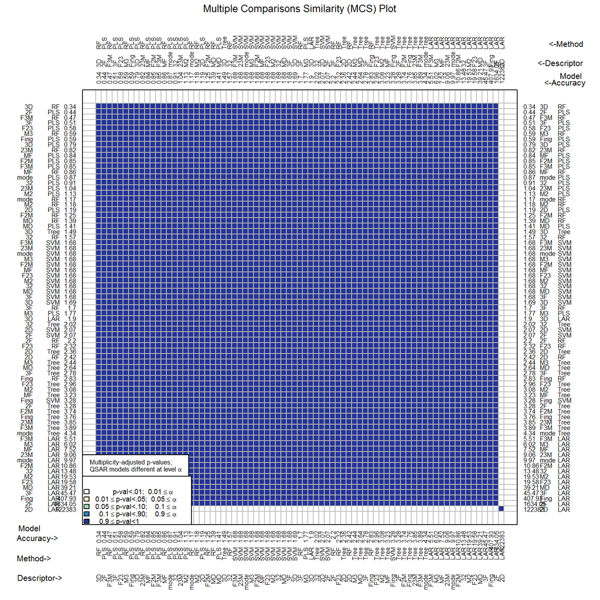

```r
CombineSplits(cml, "RMSE")
```